# synteny_blocks_tmp

## Homology determination between *Mus musculus* and *Danio rerio* analysis

### Introduction

This part of the work describes the analysis that was performed to continue analyzing Tbx5 transcription factor and it’s impact to heart cells’ regeneration.

The main purpose of the analysis was to determine the similarity of *Mus musculus* and *Danio rerio* genomes by using various bioinformatical tools in order to identify synteny blocks between beforementioned organisms.

The samples that were used in the analysis are described in the previous analysis and can be viewed here. The results of the Tbx5 transcription factor abundance in *Mus musculus* organism analysis can be found here.

### Synteny blocks by chromosome in *Mus musculus*

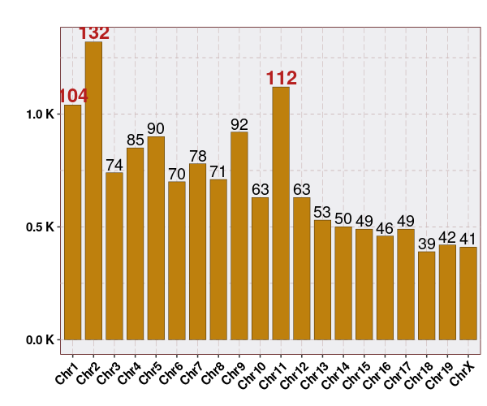

```r
# nolint start
chr_syn <- as.data.frame(table(synteny_blocks[, 6]))
colnames(chr_syn) <- c("Chr", "Freq")
chr_syn$Chr <- sub("^", "Chr", chr_syn$Chr)
chr_order <- c(paste0("Chr", 1:19), "ChrX")
chr_syn$Chr <- factor(chr_syn$Chr, levels = chr_order)

chr_syn <- chr_syn[order(chr_syn$Chr), ]
colours <- ifelse(chr_syn$Freq >= 100, "#b61f1f","black")
sizes <- ifelse(chr_syn$Freq >= 100, 6, 5)
bold <- ifelse(chr_syn$Freq >= 100, 2, 0)

plot0 <- ggplot(chr_syn, aes(x = Chr, y = Freq)) +
            geom_bar(width = 0.8, size = 0.2, fill = "#be800d",
                     color = "#523a0f", stat = 'identity',
                     position = position_dodge(0.5)) +
            geom_text(aes(label = Freq), colour = colours, vjust = -0.2,
                    hjust = 0.5, size = sizes, fontface = bold) +
            labs(title = "", x = "", y = "") +
            ylim(0, 2.5) +
            scale_y_continuous(labels = label_number(suffix = " K",
                                                     scale = 1e-2)) +
            theme(panel.background = element_rect(fill = "#eeeef1",
                                                  colour = "#4c0001"),
                  panel.grid.major.y = element_line(colour = "#cab5b5",
                                           size = 0.3, linetype = "dashed"),
                  panel.grid.minor.y = element_line(colour = "#cab5b5",
                                           size = 0.3, linetype = "dashed"),
                  panel.grid.major.x = element_line(colour = "#cab5b5",
                                           size = 0.2, linetype = "longdash"),
                  panel.grid.minor.x = element_line(colour = "#cab5b5",
                                           size = 0.2, linetype = "longdash"),
                  axis.text.x = element_text(angle = 45, hjust = 1, vjust = 1,
                                   size = 11, face = "bold", color = "black"),
                  axis.text.y = element_text(size = 11, face = "bold",
                                   color = "black"),
                  axis.title.x = element_text(size = 2),
                  axis.title.y = element_text(size = 16),
                  plot.title = element_text(hjust = 0.5, face = "bold"),
                  legend.title = element_text(face = "bold", size = 10),
                  legend.text = element_text(size = 10))

# png(file = paste0(FIGURES, "Synteny_blocks_MM_chr.png"), width = 700)
# plot0
# dev.off()
plot0
```

```r
# nolint end
```

### Synteny blocks by chromosome in *Danio rerio*

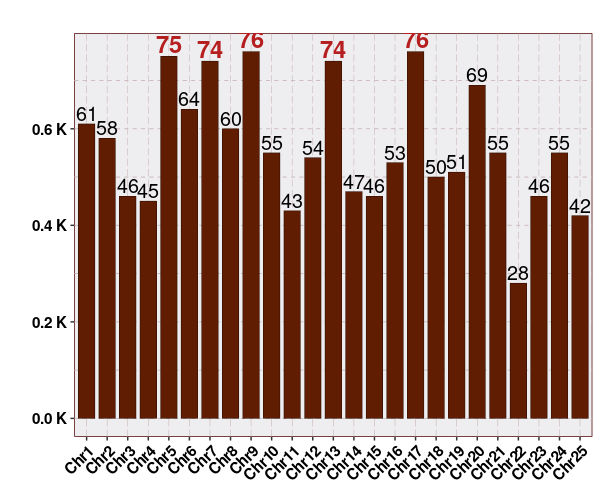

```r
# nolint start
chr_syn <- as.data.frame(table(synteny_blocks[, 2]))
colnames(chr_syn) <- c("Chr", "Freq")
chr_syn$Chr <- sub("^", "Chr", chr_syn$Chr)
chr_order <- c(paste0("Chr", 1:25))
chr_syn$Chr <- factor(chr_syn$Chr, levels = chr_order)

chr_syn <- chr_syn[order(chr_syn$Chr), ]
colours <- ifelse(chr_syn$Freq >= 70, "#b61f1f","black")
sizes <- ifelse(chr_syn$Freq >= 70, 6, 5)
bold <- ifelse(chr_syn$Freq >= 70, 2, 0)

plot1 <- ggplot(chr_syn, aes(x = Chr, y = Freq)) +
    geom_bar(width = 0.8, size = 0.2, fill = "#611d02", color = "#310f01",
             stat = 'identity', position = position_dodge(0.5)) +
    geom_text(aes(label = Freq), colour = colours, vjust = -0.2, hjust = 0.5,
              size = sizes, fontface = bold) +
    labs(title = "", x = "", y = "") +
    ylim(0, 2.5) +
    scale_y_continuous(labels = label_number(suffix = " K", scale = 1e-2)) +
    theme(panel.background = element_rect(fill = "#eeeef1",
                                          colour = "#4c0001"),
          panel.grid.major.y = element_line(colour = "#cab5b5", size = 0.3,
                                            linetype = "dashed"),
          panel.grid.minor.y = element_line(colour = "#cab5b5", size = 0.3,
                                            linetype = "dashed"),
          panel.grid.major.x = element_line(colour = "#cab5b5", size = 0.2,
                                            linetype = "longdash"),
          panel.grid.minor.x = element_line(colour = "#cab5b5", size = 0.2,
                                            linetype = "longdash"),
          axis.text.x = element_text(angle = 45, hjust = 1, vjust = 1,
                                     size = 11, face = "bold",
                                     color = "black"),
          axis.text.y = element_text(size = 11, face = "bold",
                                     color = "black"),
          axis.title.x = element_text(size = 2),
          axis.title.y = element_text(size = 16),
          plot.title = element_text(hjust = 0.5, face = "bold"),
          legend.title = element_text(face = "bold", size = 10),
          legend.text = element_text(size = 10))

# png(file = paste0(FIGURES, "Synteny_blocks_DR_chr.png"), width = 700)
# plot1
# dev.off()
plot1
```

```r
# nolint end
```

### Synteny blocks percentage in sample peaks

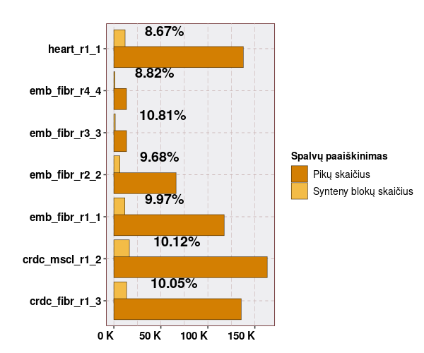

```r
# nolint start
indicators <- c("synteny_overlaps", "peak_count")
percentages <- c()

df_final <- data.frame(matrix(ncol = 4, nrow = 0))
colnames(df_final) <- c("names", "indicator", "value", "percentage")

# Determining whether overlaps between synteny blocks and peaks exist:
for (i in 1:length(grl)) {
    #print(paste("Reading peak file:", i))

    total_peaks = length(grl[[i]])
    #print(paste("Total peak count:", total_peaks))
    # print(paste("Overlap count:", length(subsetByOverlaps(syn_grange, grl[[i]]))))
    # percentage = length(subsetByOverlaps(syn_grange, grl[[i]])) / length(grl[[i]])

    overlap_count = length(subsetByOverlaps(grl[[i]], syn_grange))
    #print(paste("Overlap count:", overlap_count))

    values <- c(overlap_count, total_peaks)

    for (y in 1:length(indicators)) {
        row = c(samples$Graph_names[i], indicators[y], values[y],
                (overlap_count / total_peaks) * 100)
        df_final[nrow(df_final) + 1, ] <- row
    }
}

plot2 <- ggplot(df_final, aes(fill = indicator, y = as.numeric(value),
                          x = names)) +
            geom_bar(width = 1, size = 0.2, colour = "#3f2704",
                     stat = 'identity', position = position_dodge(0.8)) +
            geom_text(aes(label = ifelse(indicator == "synteny_overlaps",
                                         paste0(round(as.numeric(percentage),
                                                      digits = 2), "%"), ""),
                          fontface = 2), vjust = -1.2, hjust = -0.5, size = 5) +
            labs(title = "", x = "", y = "") +
            scale_fill_manual(values = c("#d37f02", "#f3bc47"),
                              labels = c("Pikų skaičius",
                                         "Synteny blokų skaičius")) +
            scale_y_continuous(labels = label_number(suffix = " K",
                                                     scale = 1e-3)) +
            guides(fill = guide_legend(title = "Spalvų paaiškinimas")) +
            theme(panel.background = element_rect(fill = "#eeeef1",
                                                  colour = "#4c0001"),
                  panel.grid.major.y = element_line(colour = "#cab5b5",
                                           size = 0.3, linetype = "dashed"),
                  panel.grid.minor.y = element_line(colour = "#cab5b5",
                                           size = 0.3, linetype = "dashed"),
                  panel.grid.major.x = element_line(colour = "#cab5b5",
                                           size = 0.2, linetype = "longdash"),
                  panel.grid.minor.x = element_line(colour = "#cab5b5",
                                           size = 0.2, linetype = "longdash"),
                  axis.text.x = element_text(angle = 0, hjust = 1, vjust = 1,
                                   size = 11, face = "bold", color = "black"),
                  axis.text.y = element_text(size = 11, face = "bold",
                                   color = "black"),
                  axis.title.x = element_text(size = 2),
                  axis.title.y = element_text(size = 16),
                  plot.title = element_text(hjust = 0.5, face = "bold"),
                  legend.title = element_text(face = "bold", size = 10),
                  legend.text = element_text(size = 10)) +
            coord_flip()

# png(file = paste0(FIGURES, "Synteny_blocks_peaks.png"), width = 700)
# plot2
# dev.off()
plot2
```

```r
# nolint end
```

### Peak annotation

[output not shown]

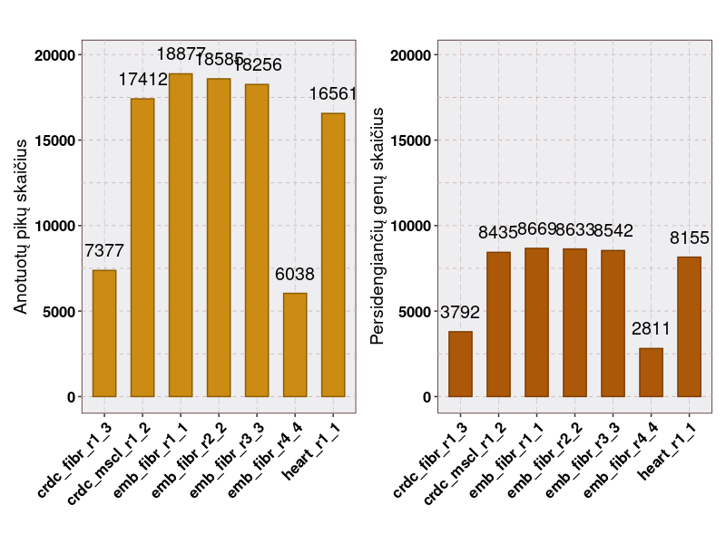

```r
# nolint start
annot_peaks <- data.frame(sample_names, annotated_genes, intersect_genes)
colnames(annot_peaks) <- c("sample", "annotated_genes", "intersecting_genes")

plot3 <- ggplot(annot_peaks, aes(x = sample_names, y = annotated_genes)) +
            geom_bar(stat = "identity", fill = "#cc8b12", width = .6,
                     color = "#8d5c00") +
            labs(title = "", x = "", y = "Anotuotų pikų skaičius") +
            ylim(0, max(annotated_genes) + 1000) +
            geom_text(aes(label = annotated_genes), color = "#030101", size = 5,
                          vjust = -1) +
            theme(axis.text = element_text(size = 10, colour = "black"),
                  axis.text.x = element_text(angle = 45, hjust = 1, size = 12,
                                             vjust = 1, face = "bold"),
                  axis.text.y = element_text(size = 12, face = "bold"),
                  axis.title.x = element_text(size = 14, colour = "black"),
                  axis.title.y = element_text(size = 14, colour = "black"),
                  panel.grid.major = element_line(color = "#eeeeee"),
                  plot.title = element_text(hjust = 0.5, size = 16,
                                            face = "bold"),
                  panel.background = element_rect(fill = "#eeeef1",
                                                  colour = "#3a1010"),
                  panel.grid.major.y = element_line(colour = "#cab5b5",
                                           size = 0.3, linetype = "dashed"),
                  panel.grid.minor.y = element_line(colour = "#cab5b5",
                                           size = 0.3, linetype = "dashed"),
                  panel.grid.major.x = element_line(colour = "#cab5b5",
                                           size = 0.2, linetype = "longdash"),
                  panel.grid.minor.x = element_line(colour = "#cab5b5",
                                           size = 0.2, linetype = "longdash"),
                  legend.position = c(0.777, 0.788))

plot4 <- ggplot(annot_peaks, aes(x = sample_names, y = intersect_genes)) +
            geom_bar(stat = "identity", fill = "#ac5809", width = .6,
                     color = "#7e3d00") +
            labs(title = "", x = "", y = "Persidengiančių genų skaičius") +
            ylim(0, max(annotated_genes) + 1000) +
            geom_text(aes(label = intersect_genes), color = "#030101", size = 5,
                          vjust = -1) +
            theme(axis.text = element_text(size = 10, colour = "black"),
                  axis.text.x = element_text(angle = 45, hjust = 1, size = 12,
                                             vjust = 1, face = "bold"),
                  axis.text.y = element_text(size = 12, face = "bold"),
                  axis.title.x = element_text(size = 14, colour = "black"),
                  axis.title.y = element_text(size = 14, colour = "black"),
                  panel.grid.major = element_line(color = "#eeeeee"),
                  plot.title = element_text(hjust = 0.5, size = 16,
                                            face = "bold"),
                  panel.background = element_rect(fill = "#eeeef1",
                                                  colour = "#3a1010"),
                  panel.grid.major.y = element_line(colour = "#cab5b5",
                                           size = 0.3, linetype = "dashed"),
                  panel.grid.minor.y = element_line(colour = "#cab5b5",
                                           size = 0.3, linetype = "dashed"),
                  panel.grid.major.x = element_line(colour = "#cab5b5",
                                           size = 0.2, linetype = "longdash"),
                  panel.grid.minor.x = element_line(colour = "#cab5b5",
                                           size = 0.2, linetype = "longdash"),
                  legend.position = c(0.777, 0.788))

# png(file = paste0(FIGURES, "Annotated_genes.png"), width = 700)
# plot3 + plot4
# dev.off()
plot3 + plot4
```

```r
# nolint end
```

**Click to see page metadata**

Computation Started: `2023-01-23 21:30:48`

Finished in `3.11 mins`

**Git Log**

No git history available for this page

**Packages**

[output not shown]

[output cut: 145 more lines]

**System Information**

|  | systemInfo |
| --- | --- |
| version | R version 4.2.2 Patched (2022-11-10 r83330) |
| platform | x86_64-pc-linux-gnu (64-bit) |
| locale | lt_LT.utf8 |
| OS | Linux Mint 20.3 |
| UI | X11 |

**Scikick Configuration**

```bash
cat scikick.yml
```

[output not shown]

**Functions**